# how_to_run_package

Parkinson’s disease (PD) is a neurodegenerative disease characterized by intraneuronal ɑ-synuclein aggregates known as Lewy pathology. Using GeoMx bulk spatial transcriptomics, we identified a molecular signature, Lewy-Associated Molecular Dysfunction from Aggregates (LAMDA), consisting of downregulated DNA repair, mitochondrial, and synaptic pathways in cortex of post-mortem PD and mouse model brains. Previous single-nucleus (sn) transcriptomics studies in PD lacked resolution on aggregate status, making it unclear how sn alterations align with the LAMDA signature. This package enables integration of bulk spatial and sn transcriptomics data and apply non-negative matrix factorization to learn shared features across data types in a low-dimensional space (aim 1) and transfer “spatial” labels from the bulk to sn data by machine learning (aim 2).

Load in devtools to install package

```r
library(devtools)
```

# BEn present from here

```r
#cahnge below libpath to directory with sufficient storage for large packages on an HPC environment
#.libPaths(c("/varidata/research/projects/henderson/THOMAS/R/4.4/library", .libPaths()))

install_github("Goralsth/spatialintegration")
```

```
## Using GitHub PAT from the git credential store.
```

```
## sass (0.4.9 -> 0.4.10) [CRAN]
```

```
## Installing 1 packages: sass
```

[output not shown]

```r
library(SpatialIntegration)
```

```r
#load the data
data(seurat_merge)
```

```r
is(seurat_merge, "Seurat")
```

```
## [1] TRUE
```

```r
seurat_merge
```

```
## An object of class Seurat
## 8028 features across 6500 samples within 1 assay
## Active assay: RNA (8028 features, 0 variable features)
##  1 layer present: counts
```

Find contribution to overall dataset to avoid NMF fitting to only 1 data set

```r
#get indiceds of geomx data
geo_ind<-is.na(seurat_merge@meta.data[["specimen_name"]])

#get sum of geomx data
sum(seurat_merge@assays[["RNA"]]@layers[["counts"]][geo_ind])
```

```
## [1] 10715420
```

```r
#get sum of allen data
sum(seurat_merge@assays[["RNA"]]@layers[["counts"]][-geo_ind])
```

```
## [1] 139261451
```

```r
#for whatever reason, the singlet package will not load as a dependency, so load it here
library(singlet)
```

Run NMF on the merged dataset. The process and run nmf function will do the rescaling for us (allen is shrunk to scale to geomx). NMF rank 15 was predetermined

```r
seurat_merge<-process_and_run_nmf(seurat_merge, nmf_rank = 15)
```

```
## Finding variable features for layer counts
```

[output not shown]

[output not shown]

[output cut: 54 more lines]

# Ben ends presentation here

perform_gsea_and_clustering computes umap and pca clusters, runs nmf. makes comparisons of pca and nmf clusters and runs GSEA for each nmf factor

```r
seurat_merge<-perform_gsea_and_clustering(seurat_merge)
```

[output not shown]

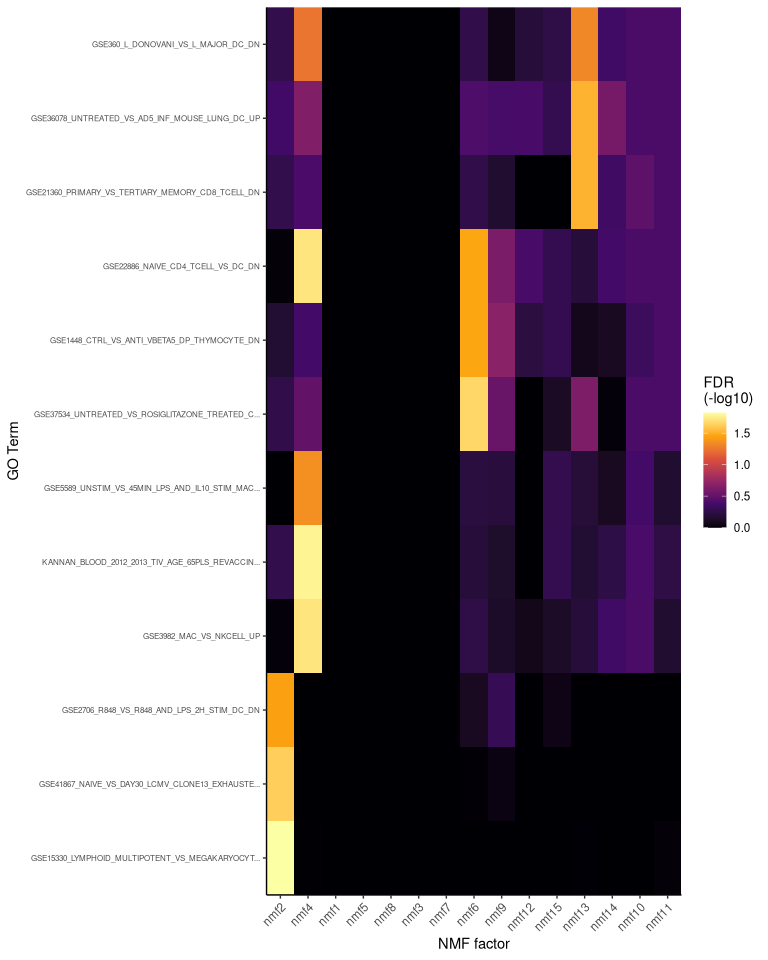

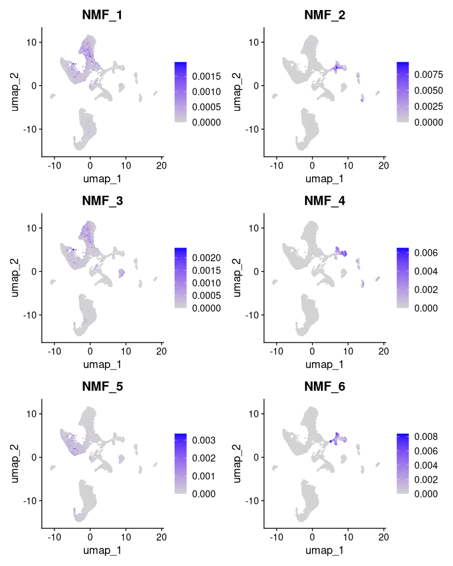

```
## No 'cell_type' column found in metadata for PCA comparison.
```

View plots.

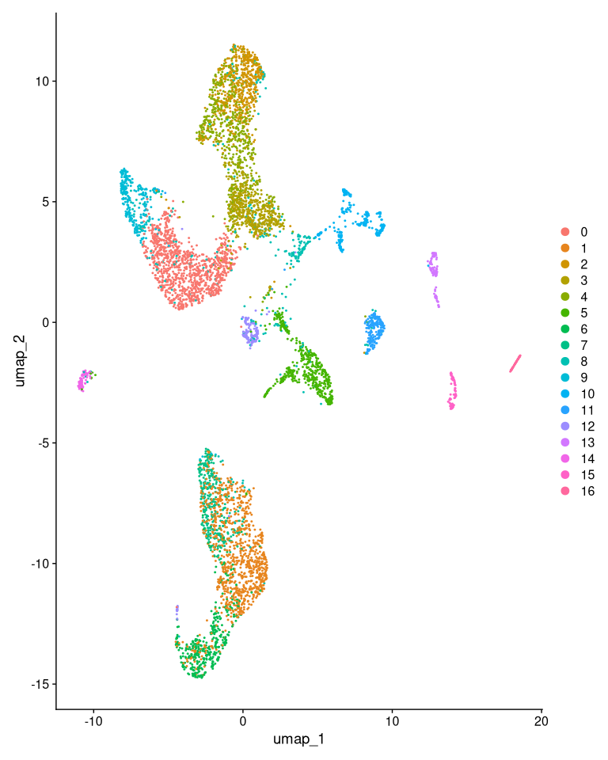

```r
#View umap clusters
print(DimPlot(seurat_merge, reduction = "umap"))
```

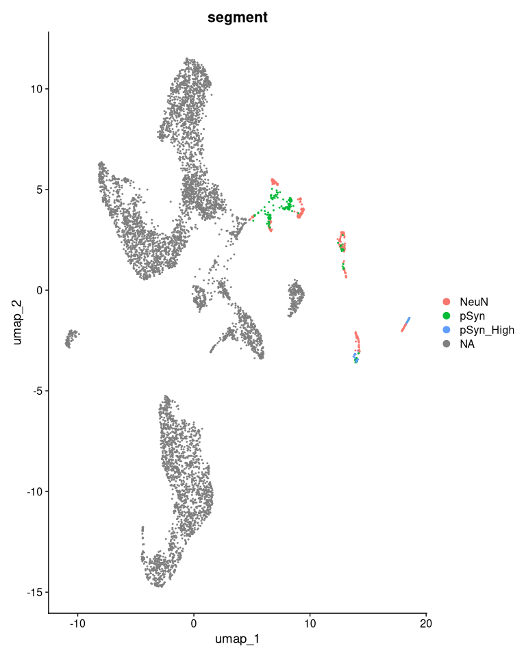

```r
#View GeoMx segment lables
print(DimPlot(seurat_merge, reduction = "umap", group.by ="segment"))
```

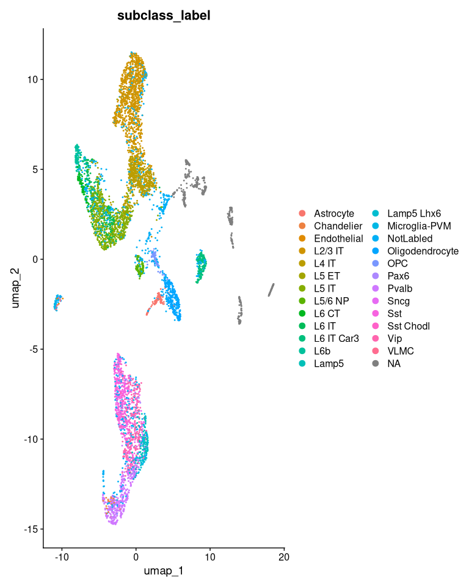

```r
#View Cell subclass labels from allen
print(DimPlot(seurat_merge, reduction = "umap", group.by ="subclass_label"))
```

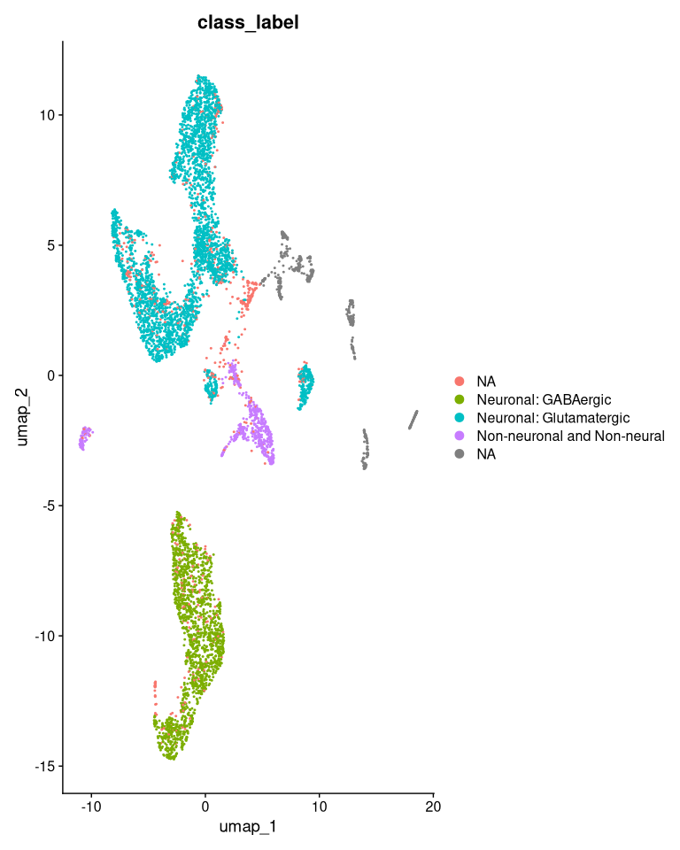

```r
#Veiw Cells labled NA in original Allen data
print(DimPlot(seurat_merge, reduction = "umap", group.by ="class_label"))
```

View each cell type label and spatial annotations correlation to each nmf factor. One hot encodes each cell type then correleates them with nmf factors

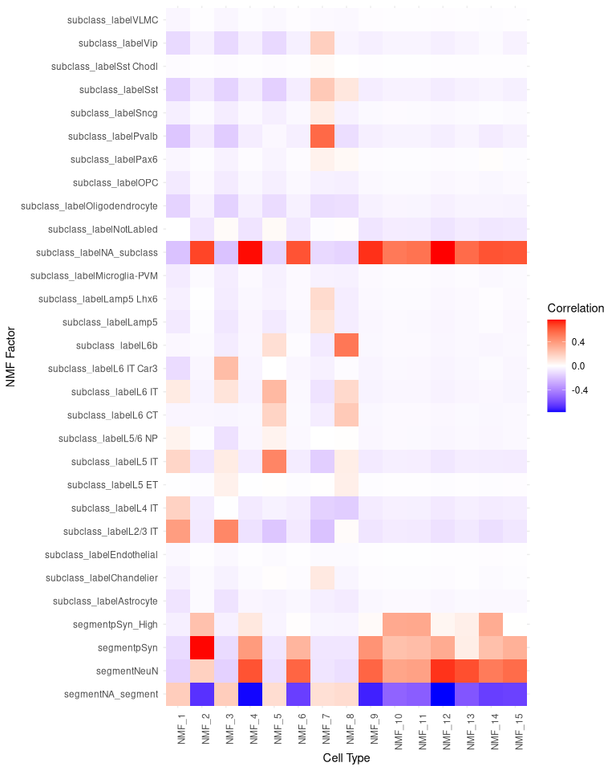

```r
plot_nmf_correlation_heatmap(seurat_merge, "cell_type_nmfFactor_corr.png")
```

View nmf loadings on umaps

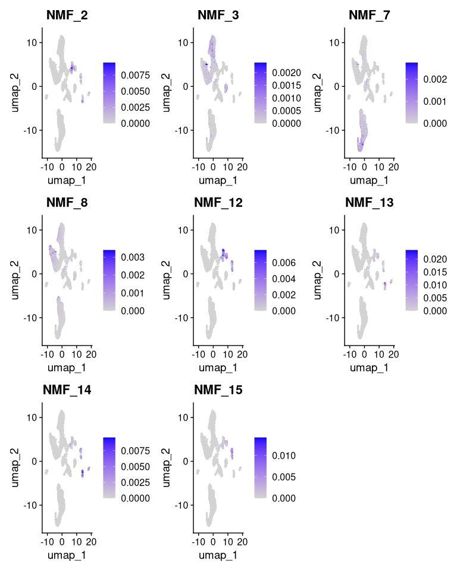

```r
FeaturePlot(seurat_merge, features = paste0("NMF_", c(2,3,7,8,c(12:15))), raster = FALSE)
```

Get top20 genesets that load with NeuN related factor

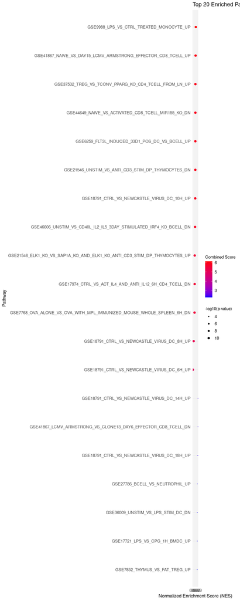

```r
plot_top20_enriched_pathways_single(seurat_object = seurat_merge,
  nmf_factor = 13,
  output_file = "top20_enriched_nmf6.pdf"
)
```

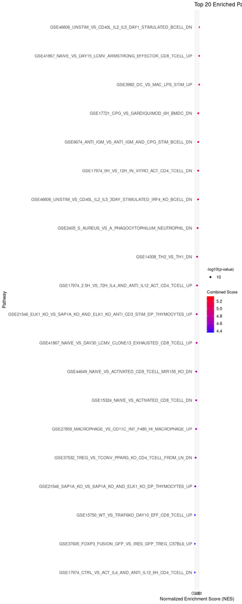

```r
#get genesets that load with pSyn related factor
plot_top20_enriched_pathways_single(seurat_object = seurat_merge,
  nmf_factor = 2,
  output_file = "top20_enriched_nmf15.pdf"
)
```

Plot GSEA heatmanp and NMF features

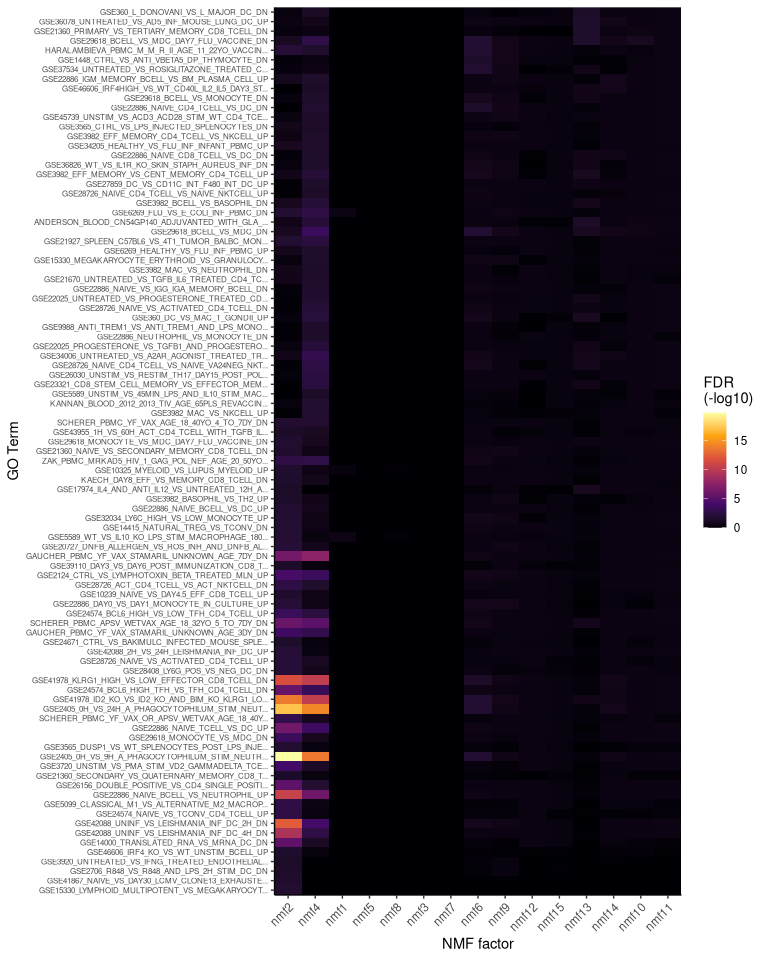

```r
GSEAHeatmap(seurat_merge, reduction = "nmf", max.terms.per.factor = 50)
```

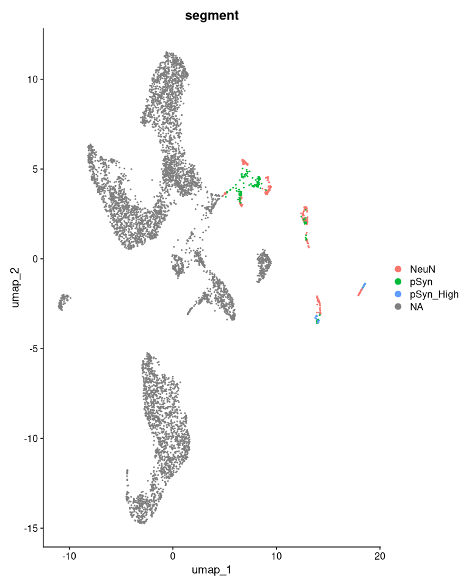

```r
DimPlot(seurat_merge, reduction = "umap", group.by ="segment")
```

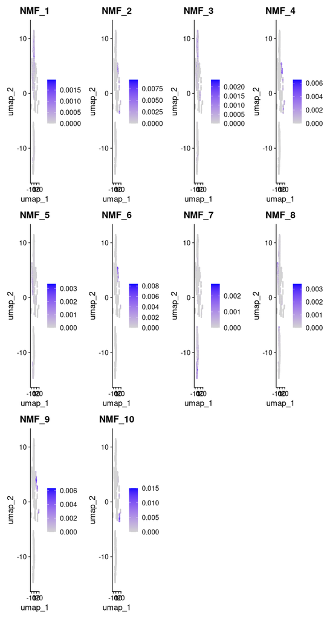

```r
FeaturePlot(seurat_merge, features = paste0("NMF_", 1:10), raster = FALSE)
```

[1] D. Agarwal, C. Sandor, V. Volpato, et al. “Common gene expression signatures in Parkinson’s disease are driven by changes in cell composition”. In: *npj Parkinson’s Disease* (2020). DOI: 10.1038/s41531-020-0112-5. https://pubmed.ncbi.nlm.nih.gov/32317022/.

[2] R. Feleke, R. Reynolds, A. Smith, et al. “Cross-platform transcriptional profiling identifies common and distinct molecular pathologies in Lewy body diseases”. In: *Acta Neuropathologica* 142 (2021), pp. 449-474. DOI: 10.1007/s00401-021-02343-x. https://doi.org/10.1007/s00401-021-02343-x.

[3] H. Fernandes, N. Patikas, S. Foskolou, et al. “Single-Cell Transcriptomics of Parkinson’s Disease Human In Vitro Models Reveals Dopamine Neuron-Specific Stress Responses”. In: *Cell Reports* 33 (2020), p. 108263. DOI: 10.1016/j.celrep.2020.108263. https://doi.org/10.1016/j.celrep.2020.108263.

[4] T. Goralski, L. Meyerdirk, L. Breton, et al. “Spatial transcriptomics reveals molecular dysfunction associated with cortical Lewy pathology”. In: *Nature Communications* 15 (2024), p. 2642. DOI: 10.1038/s41467-024-47027-8. https://doi.org/10.1038/s41467-024-47027-8.

[5] M. van den Hurk, S. Lau, M. Marchetto, et al. “Druggable transcriptomic pathways revealed in Parkinson’s patient-derived midbrain neurons”. In: *npj Parkinson’s Disease* 8 (2022), pp. 1-18. DOI: 10.1038/s41531-022-00400-0. https://doi.org/10.1038/s41531-022-00400-0.

[6] L. Yang, H. Qian, Y. Qin, et al. “scGPT: toward building a foundation model for single-cell multi-omics using generative AI”. In: *Nature Biotechnology* (2024). Accessed via PubMed. DOI: 10.1038/s41587-024-02238-2. https://pubmed.ncbi.nlm.nih.gov/38409223/.